# FinalProject

Ming Xie

2022-11-17

```r
library(reticulate)
library(tidyverse)
library(hexbin)
```

```r
library(corrplot)
library(GGally)
```

# Dataset Description **by Wen**

The dataset we will be using is the SkillCraft1 Master Table Dataset Data Set from the University of California, Irvine Machine Learning Repository dated on September 20th, 2013.

Data is available at https://archive.ics.uci.edu/ml/datasets/SkillCraft1+Master+Table+Dataset

The dataset consists of the following attributes:

| Variable | Description |
| --- | --- |
| GameID | Unique ID number for each game (integer) |
| LeagueIndex | Bronze, Silver, Gold, Platinum, Diamond, Master, GrandMaster, and Professional leagues coded 1-8 (Ordinal) |
| Age | Age of each player (integer) |
| HoursPerWeek | Reported hours spent playing per week (integer) |
| TotalHours | Reported total hours spent playing (integer) |
| APM | Action per minute (continuous) |
| SelectByHotkeys | Number of unit or building selections made using hotkeys per timestamp (continuous) |
| AssignToHotkeys | Number of units or buildings assigned to hotkeys per timestamp (continuous) |
| UniqueHotkeys | Number of unique hotkeys used per timestamp (continuous) |
| MinimapAttacks | Number of attack actions on minimap per timestamp (continuous) |
| MinimapRightClicks | number of right-clicks on minimap per timestamp (continuous) |
| NumberOfPACs | Number of PACs per timestamp (continuous) |
| GapBetweenPACs | Mean duration in milliseconds between PACs (continuous) |
| ActionLatency | Mean latency from the onset of a PACs to their first action in milliseconds (continuous) |
| ActionsInPAC | Mean number of actions within each PAC (continuous) |
| TotalMapExplored | The number of 24x24 game coordinate grids viewed by the player per timestamp (continuous) |
| WorkersMade | Number of SCVs, drones, and probes trained per timestamp (continuous) |
| UniqueUnitsMade | Unique unites made per timestamp (continuous) |
| ComplexUnitsMade | Number of ghosts, infestors, and high templars trained per timestamp (continuous) |
| ComplexAbilitiesUsed | Abilities requiring specific targeting instructions used per timestamp (continuous) |

The output variable is the *LeagueIndex* variable, which takes values from 1 to 8, corresponding to each of the leagues.

```r
#Data Preparation by Ming
skillCraft<-read.csv("SkillCraft1_Dataset.csv")
# Check the structure of the data
str(skillCraft)
```

```
## 'data.frame':    3395 obs. of  20 variables:
##  $ GameID              : int  52 55 56 57 58 60 61 72 77 81 ...
##  $ LeagueIndex         : int  5 5 4 3 3 2 1 7 4 4 ...
##  $ Age                 : chr  "27" "23" "30" "19" ...
##  $ HoursPerWeek        : chr  "10" "10" "10" "20" ...
##  $ TotalHours          : chr  "3000" "5000" "200" "400" ...
##  $ APM                 : num  144 129 70 108 123 ...
##  $ SelectByHotkeys     : num  0.00352 0.0033 0.0011 0.00103 0.00114 ...
##  $ AssignToHotkeys     : num  0.00022 0.000259 0.000336 0.000213 0.000327 ...
##  $ UniqueHotkeys       : int  7 4 4 1 2 2 6 6 2 8 ...
##  $ MinimapAttacks      : num  1.10e-04 2.94e-04 2.94e-04 5.33e-05 0.00 ...
##  $ MinimapRightClicks  : num  0.000392 0.000432 0.000461 0.000543 0.001329 ...
##  $ NumberOfPACs        : num  0.00485 0.00431 0.00293 0.00378 0.00237 ...
##  $ GapBetweenPACs      : num  32.7 32.9 44.6 29.2 22.7 ...
##  $ ActionLatency       : num  40.9 42.3 75.4 53.7 62.1 ...
##  $ ActionsInPAC        : num  4.75 4.84 4.04 4.92 9.37 ...
##  $ TotalMapExplored    : int  28 22 22 19 15 16 15 45 29 27 ...
##  $ WorkersMade         : num  0.001397 0.001193 0.000745 0.000426 0.001174 ...
##  $ UniqueUnitsMade     : int  6 5 6 7 4 6 5 9 7 6 ...
##  $ ComplexUnitsMade    : num  0 0 0 0 0 ...
##  $ ComplexAbilitiesUsed: num  0.00 2.08e-04 1.89e-04 3.84e-04 1.93e-05 ...
```

```r
# review the data
head(skillCraft)
```

```
##   GameID LeagueIndex Age HoursPerWeek TotalHours      APM SelectByHotkeys
## 1     52           5  27           10       3000 143.7180    0.0035151591
## 2     55           5  23           10       5000 129.2322    0.0033038124
## 3     56           4  30           10        200  69.9612    0.0011010906
## 4     57           3  19           20        400 107.6016    0.0010335422
## 5     58           3  32           10        500 122.8908    0.0011360136
## 6     60           2  27            6         70  44.4570    0.0009783903
##   AssignToHotkeys UniqueHotkeys MinimapAttacks MinimapRightClicks NumberOfPACs
## 1    0.0002196974             7   1.098487e-04       0.0003923169  0.004849036
## 2    0.0002594617             4   2.940566e-04       0.0004324362  0.004307064
## 3    0.0003355705             4   2.936242e-04       0.0004614094  0.002925755
## 4    0.0002131015             1   5.327537e-05       0.0005434088  0.003782551
## 5    0.0003273259             2   0.000000e+00       0.0013285582  0.002368299
## 6    0.0002552323             2   0.000000e+00       0.0000000000  0.002424707
##   GapBetweenPACs ActionLatency ActionsInPAC TotalMapExplored WorkersMade
## 1        32.6677       40.8673       4.7508               28  0.00139660
## 2        32.9194       42.3454       4.8434               22  0.00119350
## 3        44.6475       75.3548       4.0430               22  0.00074455
## 4        29.2203       53.7352       4.9155               19  0.00042620
## 5        22.6885       62.0813       9.3740               15  0.00117450
## 6        76.4405       98.7719       3.0965               16  0.00037221
##   UniqueUnitsMade ComplexUnitsMade ComplexAbilitiesUsed
## 1               6                0           0.0000e+00
## 2               5                0           2.0757e-04
## 3               6                0           1.8876e-04
## 4               7                0           3.8358e-04
## 5               4                0           1.9254e-05
## 6               6                0           0.0000e+00
```

```r
summary(skillCraft)
```

```
##      GameID       LeagueIndex        Age            HoursPerWeek
##  Min.   :   52   Min.   :1.000   Length:3395        Length:3395
##  1st Qu.: 2464   1st Qu.:3.000   Class :character   Class :character
##  Median : 4874   Median :4.000   Mode  :character   Mode  :character
##  Mean   : 4805   Mean   :4.184
##  3rd Qu.: 7108   3rd Qu.:5.000
##  Max.   :10095   Max.   :8.000
##   TotalHours             APM         SelectByHotkeys    AssignToHotkeys
##  Length:3395        Min.   : 22.06   Min.   :0.000000   Min.   :0.0000000
##  Class :character   1st Qu.: 79.90   1st Qu.:0.001258   1st Qu.:0.0002042
##  Mode  :character   Median :108.01   Median :0.002500   Median :0.0003526
##                     Mean   :117.05   Mean   :0.004299   Mean   :0.0003736
##                     3rd Qu.:142.79   3rd Qu.:0.005133   3rd Qu.:0.0004988
##                     Max.   :389.83   Max.   :0.043088   Max.   :0.0017522
##  UniqueHotkeys    MinimapAttacks      MinimapRightClicks   NumberOfPACs
##  Min.   : 0.000   Min.   :0.000e+00   Min.   :0.0000000   Min.   :0.000679
##  1st Qu.: 3.000   1st Qu.:0.000e+00   1st Qu.:0.0001401   1st Qu.:0.002754
##  Median : 4.000   Median :3.993e-05   Median :0.0002815   Median :0.003395
##  Mean   : 4.365   Mean   :9.831e-05   Mean   :0.0003874   Mean   :0.003463
##  3rd Qu.: 6.000   3rd Qu.:1.189e-04   3rd Qu.:0.0005141   3rd Qu.:0.004027
##  Max.   :10.000   Max.   :3.019e-03   Max.   :0.0040408   Max.   :0.007971
##  GapBetweenPACs    ActionLatency     ActionsInPAC    TotalMapExplored
##  Min.   :  6.667   Min.   : 24.09   Min.   : 2.039   Min.   : 5.00
##  1st Qu.: 28.958   1st Qu.: 50.45   1st Qu.: 4.273   1st Qu.:17.00
##  Median : 36.724   Median : 60.93   Median : 5.096   Median :22.00
##  Mean   : 40.362   Mean   : 63.74   Mean   : 5.273   Mean   :22.13
##  3rd Qu.: 48.291   3rd Qu.: 73.68   3rd Qu.: 6.034   3rd Qu.:27.00
##  Max.   :237.143   Max.   :176.37   Max.   :18.558   Max.   :58.00
##   WorkersMade        UniqueUnitsMade  ComplexUnitsMade    ComplexAbilitiesUsed
##  Min.   :7.698e-05   Min.   : 2.000   Min.   :0.000e+00   Min.   :0.000e+00
##  1st Qu.:6.830e-04   1st Qu.: 5.000   1st Qu.:0.000e+00   1st Qu.:0.000e+00
##  Median :9.052e-04   Median : 6.000   Median :0.000e+00   Median :2.028e-05
##  Mean   :1.032e-03   Mean   : 6.534   Mean   :5.943e-05   Mean   :1.419e-04
##  3rd Qu.:1.259e-03   3rd Qu.: 8.000   3rd Qu.:8.554e-05   3rd Qu.:1.814e-04
##  Max.   :5.149e-03   Max.   :13.000   Max.   :9.023e-04   Max.   :3.084e-03
```

```r
#Data Cleaning **by xy***

skillCraft=read.csv ("SkillCraft1_Dataset.csv",na.strings = "?")
str(skillCraft)
```

```
## 'data.frame':    3395 obs. of  20 variables:
##  $ GameID              : int  52 55 56 57 58 60 61 72 77 81 ...
##  $ LeagueIndex         : int  5 5 4 3 3 2 1 7 4 4 ...
##  $ Age                 : int  27 23 30 19 32 27 21 17 20 18 ...
##  $ HoursPerWeek        : int  10 10 10 20 10 6 8 42 14 24 ...
##  $ TotalHours          : int  3000 5000 200 400 500 70 240 10000 2708 800 ...
##  $ APM                 : num  144 129 70 108 123 ...
##  $ SelectByHotkeys     : num  0.00352 0.0033 0.0011 0.00103 0.00114 ...
##  $ AssignToHotkeys     : num  0.00022 0.000259 0.000336 0.000213 0.000327 ...
##  $ UniqueHotkeys       : int  7 4 4 1 2 2 6 6 2 8 ...
##  $ MinimapAttacks      : num  1.10e-04 2.94e-04 2.94e-04 5.33e-05 0.00 ...
##  $ MinimapRightClicks  : num  0.000392 0.000432 0.000461 0.000543 0.001329 ...
##  $ NumberOfPACs        : num  0.00485 0.00431 0.00293 0.00378 0.00237 ...
##  $ GapBetweenPACs      : num  32.7 32.9 44.6 29.2 22.7 ...
##  $ ActionLatency       : num  40.9 42.3 75.4 53.7 62.1 ...
##  $ ActionsInPAC        : num  4.75 4.84 4.04 4.92 9.37 ...
##  $ TotalMapExplored    : int  28 22 22 19 15 16 15 45 29 27 ...
##  $ WorkersMade         : num  0.001397 0.001193 0.000745 0.000426 0.001174 ...
##  $ UniqueUnitsMade     : int  6 5 6 7 4 6 5 9 7 6 ...
##  $ ComplexUnitsMade    : num  0 0 0 0 0 ...
##  $ ComplexAbilitiesUsed: num  0.00 2.08e-04 1.89e-04 3.84e-04 1.93e-05 ...
```

### DealWith missing value

```r
sum(is.na(skillCraft))
```

```
## [1] 168
```

> There are 168 missing value in this dataset,we should dealth with it.

```r
#Finding and Fixing Missing Values **by Ming**
colSums(is.na(skillCraft))
```

```
##               GameID          LeagueIndex                  Age
##                    0                    0                   55
##         HoursPerWeek           TotalHours                  APM
##                   56                   57                    0
##      SelectByHotkeys      AssignToHotkeys        UniqueHotkeys
##                    0                    0                    0
##       MinimapAttacks   MinimapRightClicks         NumberOfPACs
##                    0                    0                    0
##       GapBetweenPACs        ActionLatency         ActionsInPAC
##                    0                    0                    0
##     TotalMapExplored          WorkersMade      UniqueUnitsMade
##                    0                    0                    0
##     ComplexUnitsMade ComplexAbilitiesUsed
##                    0                    0
```

```r
#Imputation by median for attributes who have missing value.

skillCraft$Age[is.na(skillCraft$Age)] <- median(skillCraft$Age,na.rm=TRUE)
skillCraft$HoursPerWeek[is.na(skillCraft$HoursPerWeek)] <- median(skillCraft$HoursPerWeek,na.rm=TRUE)
skillCraft$TotalHours[is.na(skillCraft$TotalHours)] <- median(skillCraft$TotalHours,na.rm=TRUE)

colSums(is.na(skillCraft))
```

```
##               GameID          LeagueIndex                  Age
##                    0                    0                    0
##         HoursPerWeek           TotalHours                  APM
##                    0                    0                    0
##      SelectByHotkeys      AssignToHotkeys        UniqueHotkeys
##                    0                    0                    0
##       MinimapAttacks   MinimapRightClicks         NumberOfPACs
##                    0                    0                    0
##       GapBetweenPACs        ActionLatency         ActionsInPAC
##                    0                    0                    0
##     TotalMapExplored          WorkersMade      UniqueUnitsMade
##                    0                    0                    0
##     ComplexUnitsMade ComplexAbilitiesUsed
##                    0                    0
```

```r
#Finding duplicate values by Ming
sum(duplicated(skillCraft))
```

```
## [1] 0
```

### DealWith redundant data **by xy**

```r
skillCraftcleaned=subset(skillCraft,select =-c(GameID))
str(skillCraftcleaned)
```

```
## 'data.frame':    3395 obs. of  19 variables:
##  $ LeagueIndex         : int  5 5 4 3 3 2 1 7 4 4 ...
##  $ Age                 : num  27 23 30 19 32 27 21 17 20 18 ...
##  $ HoursPerWeek        : int  10 10 10 20 10 6 8 42 14 24 ...
##  $ TotalHours          : num  3000 5000 200 400 500 ...
##  $ APM                 : num  144 129 70 108 123 ...
##  $ SelectByHotkeys     : num  0.00352 0.0033 0.0011 0.00103 0.00114 ...
##  $ AssignToHotkeys     : num  0.00022 0.000259 0.000336 0.000213 0.000327 ...
##  $ UniqueHotkeys       : int  7 4 4 1 2 2 6 6 2 8 ...
##  $ MinimapAttacks      : num  1.10e-04 2.94e-04 2.94e-04 5.33e-05 0.00 ...
##  $ MinimapRightClicks  : num  0.000392 0.000432 0.000461 0.000543 0.001329 ...
##  $ NumberOfPACs        : num  0.00485 0.00431 0.00293 0.00378 0.00237 ...
##  $ GapBetweenPACs      : num  32.7 32.9 44.6 29.2 22.7 ...
##  $ ActionLatency       : num  40.9 42.3 75.4 53.7 62.1 ...
##  $ ActionsInPAC        : num  4.75 4.84 4.04 4.92 9.37 ...
##  $ TotalMapExplored    : int  28 22 22 19 15 16 15 45 29 27 ...
##  $ WorkersMade         : num  0.001397 0.001193 0.000745 0.000426 0.001174 ...
##  $ UniqueUnitsMade     : int  6 5 6 7 4 6 5 9 7 6 ...
##  $ ComplexUnitsMade    : num  0 0 0 0 0 ...
##  $ ComplexAbilitiesUsed: num  0.00 2.08e-04 1.89e-04 3.84e-04 1.93e-05 ...
```

> The GameID is unique, and it is not helpful for our research,so we remove this row.

### Data Exploration

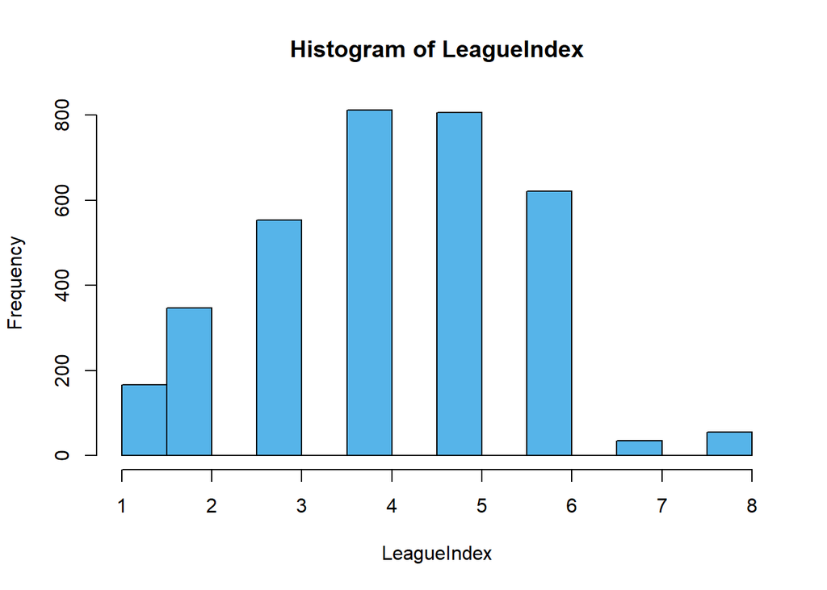

```r
# ***By Ming***

# check response Candidate: LeagueIndex and APM

# histogram of LeagueIndex
hist(skillCraftcleaned$LeagueIndex, xlab = 'LeagueIndex',main='Histogram of LeagueIndex', col="#56B4E9")
```

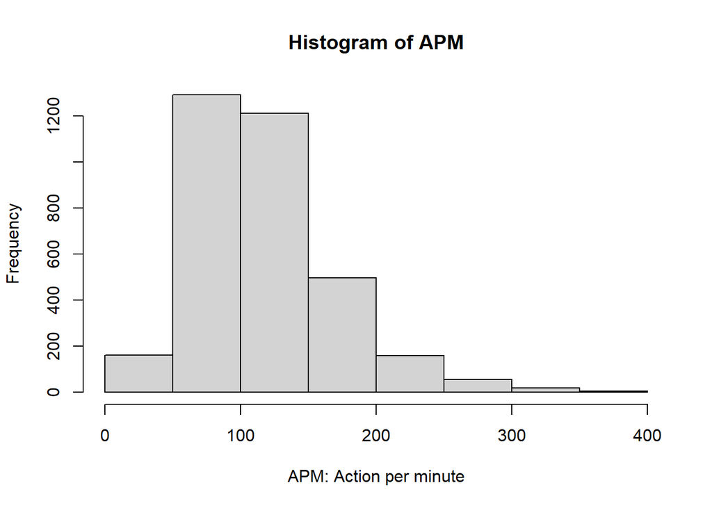

```r
# check histogram of APM

hist(skillCraftcleaned$APM, xlab = 'APM: Action per minute',main='Histogram of APM')
```

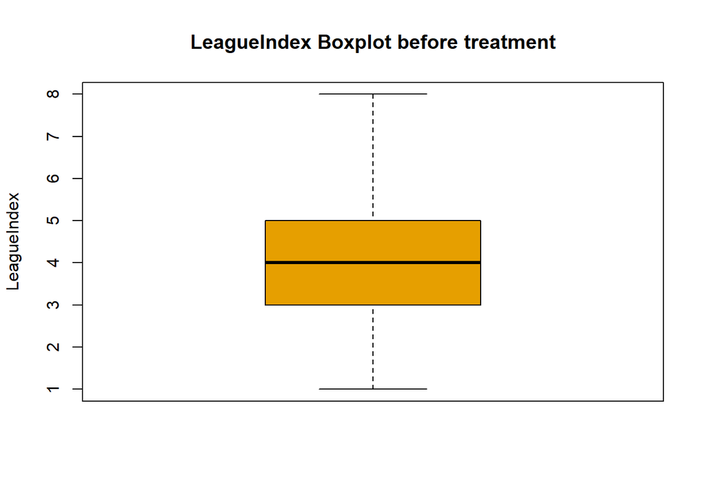

```r
#Finding Outliers
boxplot(skillCraftcleaned$LeagueIndex,col="#E69F00",main='LeagueIndex Boxplot before treatment', ylab = "LeagueIndex")
```

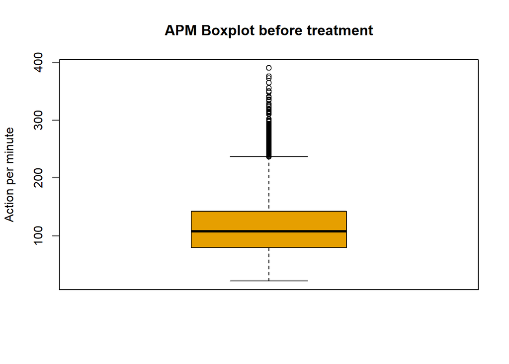

```r
boxplot(skillCraftcleaned$APM,col="#E69F00",main='APM Boxplot before treatment', ylab = "Action per minute")
```